# DEVP229: D-Lab Part 1

Evan Muzzall

1/13/2021

# 1. What is R?

R is an open source statistical programming language. A programming language is simply a means to give instructions to a computer. R is incredibly efficient for using your computer to perform computational tasks, produce graphics, and interface with other applications to enhance your data science productivity.

However, computers do not understand context - if your code instructions are not exact, you will receive an error message. Get ready! You will spend a lot of time debugging error messages and searching for help.

- Click here to learn more about R: https://en.wikipedia.org/wiki/R_(programming_language)

# 2. RStudio

### Navigating RStudio

By default, R Scripts and Markdown files will open in the upper left pane of RStudio. You should see four “window panes” in your RStudio application:

1. Markdown/Script (upper left): this is your input and is easily savable
2. Console (lower left): output appears here and functions as a nice scratch space
3. Global Environment (upper right): saved variables will appear here
4. Misc (lower right): navigate your file system, plots, install packages, view help

RStudio also has a lot of helpful customizations to improve your experience:

- Click “Tools –-> Global Options -–> Appearance” to change your editor theme, color, and font settings
- Click “Tools –-> Global Options –-> Code” and check the box that says “Soft-wrap R source files” to wrap the text in your script to the width of the script pane
- Click “Tools –-> Global Options –-> Code –> Display” and check the boxes that say “Highlight selected line” and “Highlight R function calls”
- Click “Tools” –> “Global Options” –> “RMarkdown” and **uncheck** “Show output inline for all R Markdown documents” if your output appears here!
- Learn more about RStudio: https://en.wikipedia.org/wiki/RStudio
- See the RStudio cheatsheets: https://rstudio.com/resources/cheatsheets/
- Also, click the “Tutorial” tab in the upper-right corner of RStudio to get started with the built-in tutorials.

# 3. R Markdown

There are many ways to code in RStudio. The two most common are: R Script and R Markdown.

### 1. R Script (.R)

An R Script is a plain text file with a .R file extension. Click “File” –> “New File” –> “R Script” to open one. These are useful when you do not need to transform your work into another format.

**Key points:**

1. Enter code normally
2. Use a hashtag `#` to comment your code and add text

### 2. R Markdown (.Rmd)

The second - and more extensible - is an R Markdown file. R Markdown is a lightweight markup language (this means that it does not considerably affect computation time) that can be formatted and transformed into other documents formats including HTML, PDF, MS Word, slideshows, e-books, dashboards, interactive applications, and websites. HTML files are particularly useful because they are small in size but still look vibrant and dynamic in your web browser.

Open a new R Markdown file by clicking “File” –> “New File” –> “R Markdown”.

**Key points:**

# Example - Use a single hashtag to make a large header

## Two hashtags for a secondary header

### Three hashtags for a tertiary header

This is a simple example. Text is entered normally here. Wrap your text in **double stars** to bold it. Wrap it in **double italics** to italicize it.

- Use an asterisk at the beginning of a line
- to make a bulleted list
1. Type numbers at the beginning of a line
2. to make numbered lists

Now, insert a code chunk. Load the School Lunch Dataset!

> Use a greater than symbol to insert an offset note. Press command + enter (Mac) or control + enter (PC) to run a line of code. Or, you can click the green play button to run the entire chunk!

```r
# Enter code here like you would in a plain .R Script file
# Save text outside of a code chunk to build narrative around your research
# Use hashtags inside of code chunks to make notes specifically about your code

lunch <- read.csv("School Lunch Data.csv")

# Print the dataset to the screen (will truncate based on your computer's memory limitations)

# Investigate the compact structure of the dataset
str(lunch)
```

```
## 'data.frame':    20 obs. of  4 variables:
##  $ School: chr  "Joe A. Gonsalves Elementary" "Old River Elementary" "Sierra Vista Elementary" "West Portal Elementary" ...
##  $ API   : int  960 849 722 914 754 796 802 903 844 963 ...
##  $ FLE   : int  16 0 96 44 83 90 80 46 33 6 ...
##  $ PE    : int  81 24 6 63 20 20 18 53 60 84 ...
```

```r
# Display first six rows (default) of the dataset
head(lunch)
```

```
##                        School API FLE PE
## 1 Joe A. Gonsalves Elementary 960  16 81
## 2        Old River Elementary 849   0 24
## 3     Sierra Vista Elementary 722  96  6
## 4      West Portal Elementary 914  44 63
## 5 Isabelle Jackson Elementary 754  83 20
## 6        Rio Vista Elementary 796  90 20
```

```r
# Filterable spreadsheet view (unhashtag to view)
# View(lunch)
```

Produce basic summary statistics

```r
# See length of character vectors, frequencies of factors, and six-number summaries for continuous data (i.e., numeric and integer type)
summary(lunch)
```

```
##     School               API             FLE               PE
##  Length:20          Min.   :722.0   Min.   :  0.00   Min.   : 6.00
##  Class :character   1st Qu.:779.5   1st Qu.: 32.00   1st Qu.:19.50
##  Mode  :character   Median :828.0   Median : 56.50   Median :25.50
##                     Mean   :835.8   Mean   : 54.90   Mean   :37.10
##                     3rd Qu.:887.2   3rd Qu.: 80.75   3rd Qu.:60.25
##                     Max.   :981.0   Max.   :100.00   Max.   :84.00
```

Include basic plots

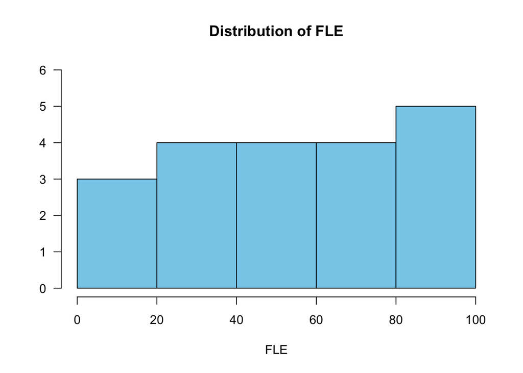

```r
# You can even add a hashtag after a line of runnable code!

hist(lunch$FLE, # column to plot
     breaks = 5, # adjust number of breaks
     col = "skyblue", # change bar color
     main = "Distribution of FLE", # change title
     xlab = "FLE", # change x-axis label
     ylab = "", # Leave blank to omit
     ylim = c(0, 6), # change y-axis limits
     las = 1) # change tickmark orientation
```

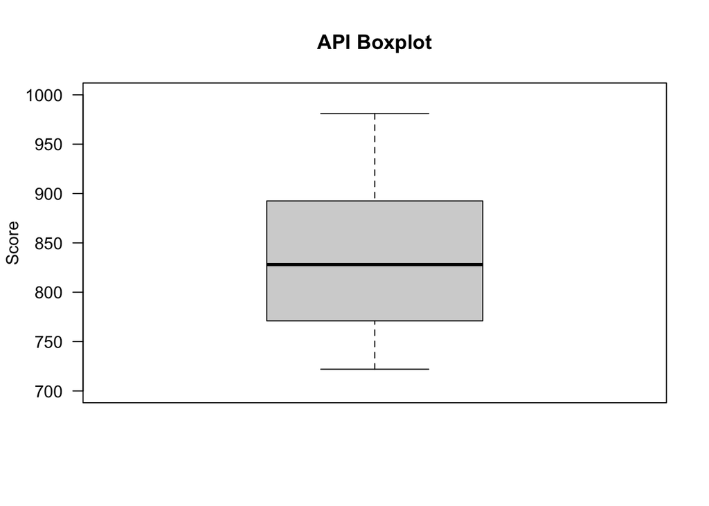

```r
boxplot(lunch$API,
        las = 1,
        ylim = c(700, 1000),
        main = "API Boxplot",
        ylab = "Score")
```

- See the ggplot2 documentation to learn the essentials of the Grammar of Graphics: https://ggplot2.tidyverse.org/

# Knitting Markdown files

**A few tips:** 1. To keep things simple, always try to keep your data in the same folder where your R Markdown file lives.

2. First, set your working directory to the folder where your data and R Markdown file are. Click “Session” –> “Set Working Directory” –> “Choose Directory” to select this folder.
3. Use the `getwd()` function to check the location. Then, use the `dir()` function to see if your data is there.

Knitting can be frustrating and tricky until you get it set up correctly. Do you get an error message?

# If you are running into errors when knitting, try:

1. Copy/paste this code into your console: `install.packages(“rmarkdown”)
2. Then try: `install.packages(“knitr”)
3. Install XQuartz by visiting this website: https://www.xquartz.org/